# Chapter 13: Analytical Dataset Development Examples

# Setup Database

```r
library(pacman)
p_load(dplyr, DBI)

# Create a database table in memory
farmers.db <-
  dbConnect(RMariaDB::MariaDB(),
            group = "/Users/nickjenkins/Documents/Workshops & Conferences/SQL for Data Scientists/SQL for Data Scientists support files/FarmersMarketDatabase.sql",
            username = "root",
            password = "Hockeydude25",
            host = "localhost",
            port = 3306)
```

The goal of this chapter is to learn how to design and build a dataset from the the Farmer’s Market database to answer each of the following questions:

- What factors correlate with fresh produce sales?
- How do sales vary by customer zip code, market distance, and demographic data?
- How does product price distribution affect market sales?

# What factors Correlate with Fresh Produce Sales?

Let’s say we’re asked the analytical question “What factors are correlated with sales of fresh produce at the farmer’s market?” To answer this we need to summarize different variables over periods of time and explore how sales during those same time periods change as each variable changes.

We could choose to summarize each value per week and then create a scatterplot of the weekly pairs of numbers to visualize the relationship between them, for example. To do that for a variety of variables, we’ll need to write a query that generates a dataset with one row per market week containing weekly summaries of each value to be explored. The question we will explore is: “As the number of different available products at the market increases, do sales of fresh produce go up or down?”

First, we need to determine what products are considered “fresh produce” then calculate sales of those products per week, and pull in other variables summarized per week. We’ll start by looking at all the different product categories to determine which make the most sense to use to answer this question.

```sql
SELECT *
FROM farmers_market.product_category
```

| product_category_id | product_category_name |
| --- | --- |
| 1 | Fresh Fruits & Vegetables |
| 2 | Packaged Pantry Goods |
| 3 | Packaged Prepared Food |
| 4 | Freshly Prepared Food |
| 5 | Plants & Flowers |
| 6 | Eggs & Meat (Fresh or Frozen) |
| 7 | Non-Edible Products |

The “Fresh Fruits & Vegetables” category is obvious, but there could also be fresh produce products in the “Plants & Flowers” and “Eggs & Meat” categories. Let’s generate a list of all products in categories 1, 5, and 6.

```sql
SELECT *
FROM farmers_market.product
WHERE product_category_id IN (1, 5, 6)
ORDER BY product_category_id
```

| product_id | product_name | product_size | product_category_id | product_qty_type |
| --- | --- | --- | --- | --- |
| 1 | Habanero Peppers - Organic | medium | 1 | lbs |
| 2 | Jalapeno Peppers - Organic | small | 1 | lbs |
| 3 | Poblano Peppers - Organic | large | 1 | unit |
| 9 | Sweet Potatoes | medium | 1 | lbs |
| 12 | Baby Salad Lettuce Mix - Bag | 1/2 lb | 1 | unit |
| 13 | Baby Salad Lettuce Mix | 1 lb | 1 | lbs |
| 14 | Red Potatoes | NA | 1 | NA |
| 15 | Red Potatoes - Small |  | 1 | NA |
| 16 | Sweet Corn | Ear | 1 | unit |
| 17 | Carrots | sold by weight | 1 | lbs |

[output cut: 6 more lines]

With the right filters, we can begin to design the dataset. We need some summary information about sales, which will need to come from the `customer_purchases` table. Data about availability comes from `vendor_inventory`.

Because this is a question about something related to sales over time, we will start with the product sales part of the question, then join other information to the results of the query.

We need to select the details needed to summarize sales per week for products in the “Fresh Fruits & Vegetables” category 1 by inner joining sales (`customer_purchases`) and products (`product`) by `product_id`.

```sql
SELECT *
FROM farmers_market.customer_purchases AS cp
  INNER JOIN farmers_market.product AS p
  ON cp.product_id = p.product_id
WHERE p.product_category_id = 1
```

| product_id | vendor_id | market_date | customer_id | quantity | cost_to_customer_per_qty | transaction_time | product_id..8 | product_name | product_size | product_category_id | product_qty_type |
| --- | --- | --- | --- | --- | --- | --- | --- | --- | --- | --- | --- |
| 1 | 7 | 2019-07-03 | 14 | 0.99 | 6.99 | 17:32:00 | 1 | Habanero Peppers - Organic | medium | 1 | lbs |
| 1 | 7 | 2019-07-03 | 14 | 2.18 | 6.99 | 18:23:00 | 1 | Habanero Peppers - Organic | medium | 1 | lbs |
| 1 | 7 | 2019-07-03 | 15 | 1.53 | 6.99 | 18:41:00 | 1 | Habanero Peppers - Organic | medium | 1 | lbs |
| 1 | 7 | 2019-07-03 | 16 | 2.02 | 6.99 | 18:18:00 | 1 | Habanero Peppers - Organic | medium | 1 | lbs |
| 1 | 7 | 2019-07-03 | 22 | 0.66 | 6.99 | 17:34:00 | 1 | Habanero Peppers - Organic | medium | 1 | lbs |
| 1 | 7 | 2019-07-06 | 4 | 0.27 | 6.99 | 12:20:00 | 1 | Habanero Peppers - Organic | medium | 1 | lbs |
| 1 | 7 | 2019-07-06 | 12 | 3.60 | 6.99 | 09:33:00 | 1 | Habanero Peppers - Organic | medium | 1 | lbs |
| 1 | 7 | 2019-07-06 | 14 | 3.04 | 6.99 | 13:05:00 | 1 | Habanero Peppers - Organic | medium | 1 | lbs |
| 1 | 7 | 2019-07-06 | 23 | 1.49 | 6.99 | 12:26:00 | 1 | Habanero Peppers - Organic | medium | 1 | lbs |
| 1 | 7 | 2019-07-06 | 23 | 2.56 | 6.99 | 12:46:00 | 1 | Habanero Peppers - Organic | medium | 1 | lbs |

[output cut: 990 more lines]

We used `INNER JOIN` instead of `LEFT JOIN` because we aren’t interested in products that don’t have purchases.

Since we are joining by week, we don’t need the `transaction_time` field and we don’t need data on the size of the product.

We can join in the `market_date_info` table to get the week number. Here we will `RIGHT JOIN` it to the other tables, because we want to know whether there are market dates with no fresh produce sales at all and the `RIGHT JOIN` will still pull in market dates with no corresponding records in the `customer_purchases` table.

```sql
SELECT
  cp.market_date,
  cp.customer_id,
  cp.quantity,
  cp.cost_to_customer_per_qty,
  p.product_category_id,
  mdi.market_date,
  mdi.market_week,
  mdi.market_year,
  mdi.market_rain_flag,
  mdi.market_snow_flag
FROM farmers_market.customer_purchases AS cp
  INNER JOIN farmers_market.product AS p
  ON cp.product_id = p.product_id
  RIGHT JOIN farmers_market.market_date_info AS mdi
  ON mdi.market_date = cp.market_date
WHERE p.product_category_id = 1
```

| market_date | customer_id | quantity | cost_to_customer_per_qty | product_category_id | market_date..6 | market_week | market_year | market_rain_flag | market_snow_flag |
| --- | --- | --- | --- | --- | --- | --- | --- | --- | --- |
| 2019-07-03 | 14 | 0.99 | 6.99 | 1 | 2019-07-03 | 27 | 2019 | 0 | 0 |
| 2019-07-03 | 14 | 2.18 | 6.99 | 1 | 2019-07-03 | 27 | 2019 | 0 | 0 |
| 2019-07-03 | 15 | 1.53 | 6.99 | 1 | 2019-07-03 | 27 | 2019 | 0 | 0 |
| 2019-07-03 | 16 | 2.02 | 6.99 | 1 | 2019-07-03 | 27 | 2019 | 0 | 0 |
| 2019-07-03 | 22 | 0.66 | 6.99 | 1 | 2019-07-03 | 27 | 2019 | 0 | 0 |
| 2019-07-06 | 4 | 0.27 | 6.99 | 1 | 2019-07-06 | 27 | 2019 | 0 | 0 |
| 2019-07-06 | 12 | 3.60 | 6.99 | 1 | 2019-07-06 | 27 | 2019 | 0 | 0 |
| 2019-07-06 | 14 | 3.04 | 6.99 | 1 | 2019-07-06 | 27 | 2019 | 0 | 0 |
| 2019-07-06 | 23 | 1.49 | 6.99 | 1 | 2019-07-06 | 27 | 2019 | 0 | 0 |
| 2019-07-06 | 23 | 2.56 | 6.99 | 1 | 2019-07-06 | 27 | 2019 | 0 | 0 |

[output cut: 990 more lines]

With this query we still only get rows were customer purchases were made even though there are dates where no purchases were made. This is happening because the `WHERE` clause if filtering out the results without purchases. The solution is to put the filter in the `JOIN ON` clause instead of the `WHERE` clause.

```sql
SELECT
  cp.market_date,
  cp.customer_id,
  cp.quantity,
  cp.cost_to_customer_per_qty,
  p.product_category_id,
  mdi.market_date,
  mdi.market_week,
  mdi.market_year,
  mdi.market_rain_flag,
  mdi.market_snow_flag
FROM farmers_market.customer_purchases AS cp
  INNER JOIN farmers_market.product AS p
  ON cp.product_id = p.product_id
  AND p.product_category_id = 1
  RIGHT JOIN farmers_market.market_date_info AS mdi
  ON mdi.market_date = cp.market_date
```

| market_date | customer_id | quantity | cost_to_customer_per_qty | product_category_id | market_date..6 | market_week | market_year | market_rain_flag | market_snow_flag |
| --- | --- | --- | --- | --- | --- | --- | --- | --- | --- |
|  | NA | NA | NA | NA | 2019-03-02 | 9 | 2019 | 0 | 0 |
|  | NA | NA | NA | NA | 2019-03-09 | 10 | 2019 | 0 | 1 |
|  | NA | NA | NA | NA | 2019-03-13 | 11 | 2019 | 0 | 0 |
|  | NA | NA | NA | NA | 2019-03-16 | 11 | 2019 | 0 | 0 |
|  | NA | NA | NA | NA | 2019-03-20 | 12 | 2019 | 1 | 0 |
|  | NA | NA | NA | NA | 2019-03-23 | 12 | 2019 | 1 | 0 |
|  | NA | NA | NA | NA | 2019-03-27 | 13 | 2019 | 0 | 0 |
|  | NA | NA | NA | NA | 2019-03-30 | 13 | 2019 | 1 | 0 |
|  | NA | NA | NA | NA | 2019-04-03 | 14 | 2019 | 0 | 0 |
|  | NA | NA | NA | NA | 2019-04-06 | 14 | 2019 | 0 | 0 |

[output cut: 990 more lines]

We can summarize the customer purchases to one row per week to get sales per week by grouping on `market_year` and `market_week`, and we don’t need the other columns with additional details about the purchases. Here we’ll also use the `COALESCE` function which returns the first non-`NULL` value in a list of values. For example, if we had a query that returns a market date with no sales in product category 1, the `weekly_category1_sales` value would be `NULL`. If we want it to be 0 instead, we can use the syntax `COALSCE([value 1], 0)` which will return a - if “value 1” is `NULL`.

To summarize, in that final line before the `FROM` clause, we’re adding up the sales, converting the result to 0 if there are no sales, then rounding the numeric result to two digits.

```sql
SELECT
  mdi.market_year,
  mdi.market_week,
  MAX(mdi.market_rain_flag) AS market_week_rain_flag,
  MAX(mdi.market_snow_flag) AS market_week_snow_flag,
  MIN(mdi.market_min_temp) AS min_temp,
  MAX(mdi.market_max_temp) AS max_temp,
  MIN(mdi.market_season) AS market_season,
  ROUND(COALESCE(SUM(cp.quantity * cp.cost_to_customer_per_qty), 0), 2) AS
    weekly_category1_sales
FROM farmers_market.customer_purchases AS cp
  INNER JOIN farmers_market.product AS p
  ON cp.product_id = p.product_id
  AND p.product_category_id = 1
  RIGHT JOIN farmers_market.market_date_info AS mdi
  ON mdi.market_date = cp.market_date
GROUP BY mdi.market_year, mdi.market_week
```

| market_year | market_week | market_week_rain_flag | market_week_snow_flag | min_temp | max_temp | market_season | weekly_category1_sales |
| --- | --- | --- | --- | --- | --- | --- | --- |
| 2019 | 9 | 0 | 0 | 34 | 42 | Spring | 0.00 |
| 2019 | 10 | 0 | 1 | 28 | 32 | Spring | 0.00 |
| 2019 | 11 | 0 | 0 | 33 | 60 | Spring | 0.00 |
| 2019 | 12 | 1 | 0 | 40 | 51 | Spring | 0.00 |
| 2019 | 13 | 1 | 0 | 39 | 62 | Spring | 0.00 |
| 2019 | 14 | 0 | 0 | 33 | 65 | Spring | 0.00 |
| 2019 | 15 | 0 | 0 | 48 | 65 | Spring | 0.00 |
| 2019 | 16 | 0 | 0 | 49 | 60 | Spring | 0.00 |
| 2019 | 17 | 0 | 0 | 51 | 68 | Spring | 0.00 |
| 2019 | 18 | 0 | 0 | 53 | 64 | Spring | 0.00 |

[output cut: 66 more lines]

Now we have total sales by week.

Some other aggregate values we could add to the dataset include the number of vendors carrying products in the category, the volume of inventory available for purchase, and special high-demand product seasonal availability. These values come from the `vendor_inventory` table and we will joing it to the `product` and `market_date_info` tables the same way and filter `product_category_id = 1` in the `JOIN` statement.

```sql
SELECT
  mdi.market_date,
  mdi.market_year,
  mdi.market_week,
  vi.*,
  p.*
FROM farmers_market.vendor_inventory AS vi
  INNER JOIN farmers_market.product AS p
    ON vi.product_id = p.product_id
    AND p.product_category_id = 1
  RIGHT JOIN farmers_market.market_date_info AS mdi
    ON mdi.market_date = vi.market_date
```

| market_date | market_year | market_week | market_date..4 | quantity | vendor_id | product_id | original_price | product_id..9 | product_name | product_size | product_category_id | product_qty_type |
| --- | --- | --- | --- | --- | --- | --- | --- | --- | --- | --- | --- | --- |
| 2019-03-02 | 2019 | 9 |  | NA | NA | NA | NA | NA | NA | NA | NA | NA |
| 2019-03-09 | 2019 | 10 |  | NA | NA | NA | NA | NA | NA | NA | NA | NA |
| 2019-03-13 | 2019 | 11 |  | NA | NA | NA | NA | NA | NA | NA | NA | NA |
| 2019-03-16 | 2019 | 11 |  | NA | NA | NA | NA | NA | NA | NA | NA | NA |
| 2019-03-20 | 2019 | 12 |  | NA | NA | NA | NA | NA | NA | NA | NA | NA |
| 2019-03-23 | 2019 | 12 |  | NA | NA | NA | NA | NA | NA | NA | NA | NA |
| 2019-03-27 | 2019 | 13 |  | NA | NA | NA | NA | NA | NA | NA | NA | NA |
| 2019-03-30 | 2019 | 13 |  | NA | NA | NA | NA | NA | NA | NA | NA | NA |
| 2019-04-03 | 2019 | 14 |  | NA | NA | NA | NA | NA | NA | NA | NA | NA |
| 2019-04-06 | 2019 | 14 |  | NA | NA | NA | NA | NA | NA | NA | NA | NA |

[output cut: 299 more lines]

Suppose we suspect that when the sweet corn vendors are at the market, some customers some that don’t come at any other time of year. We want to know if overall fresh produce sales go up during the weeks when corn is available, so we’ll create a product availability flag for product 16, sweet corn, called `corn_available_flag`:

```sql
SELECT
  mdi.market_year,
  mdi.market_week,
  COUNT(DISTINCT vi.vendor_id) AS vendor_count,
  COUNT(DISTINCT vi.product_id) AS unique_product_count,
  SUM(CASE WHEN p.product_qty_type = "unit" THEN vi.quantity ELSE 0 END) AS
    unit_products_qty,
  SUM(CASE WHEN p.product_qty_type = "lbs" THEN vi.quantity ELSE 0 END) AS
    bulk_products_lbs,
  ROUND(COALESCE(SUM(vi.quantity * vi.original_price), 0), 2) AS
    total_product_value,
  MAX(CASE WHEN p.product_id = 16 THEN 1 ELSE 0 END) AS corn_available_flag
FROM farmers_market.vendor_inventory AS vi
  INNER JOIN farmers_market.product AS p
    ON vi.product_id = p.product_id
  RIGHT JOIN farmers_market.market_date_info AS mdi
    ON mdi.market_date = vi.market_date
  GROUP BY mdi.market_year, mdi.market_week
```

| market_year | market_week | vendor_count | unique_product_count | unit_products_qty | bulk_products_lbs | total_product_value | corn_available_flag |
| --- | --- | --- | --- | --- | --- | --- | --- |
| 2019 | 10 | 0 | 0 | 0 | 0.00 | 0.00 | 0 |
| 2019 | 11 | 0 | 0 | 0 | 0.00 | 0.00 | 0 |
| 2019 | 12 | 0 | 0 | 0 | 0.00 | 0.00 | 0 |
| 2019 | 13 | 0 | 0 | 0 | 0.00 | 0.00 | 0 |
| 2019 | 14 | 2 | 4 | 153 | 0.00 | 1185.50 | 0 |
| 2019 | 15 | 2 | 4 | 135 | 0.00 | 1038.00 | 0 |
| 2019 | 16 | 2 | 4 | 156 | 0.00 | 1159.00 | 0 |
| 2019 | 17 | 2 | 4 | 131 | 0.00 | 964.00 | 0 |
| 2019 | 18 | 2 | 4 | 147 | 0.00 | 1137.00 | 0 |
| 2019 | 19 | 2 | 4 | 150 | 0.00 | 1108.50 | 0 |

[output cut: 66 more lines]

I would be better to have a count of vendors selling products available at the entire market, in addition to the product availability for product category 1. To avoid joining in another query, we will remove the `product_category_id` filter and use `CASE` statements to create a set of fields that provides the same metrics.

```sql
SELECT
  mdi.market_year,
  mdi.market_week,
  COUNT(DISTINCT vi.vendor_id) AS vendor_count,
  COUNT(DISTINCT CASE WHEN p.product_category_id = 1
    THEN vi.vendor_id
    ELSE NULL END) AS vendor_count_product_category1,
  COUNT(DISTINCT vi.product_id) AS unique_product_count,
  SUM(CASE WHEN p.product_qty_type = "unit" THEN vi.quantity ELSE 0 END) AS
    unit_products_qty,
  SUM(CASE WHEN p.product_category_id = 1 AND p.product_qty_type = "unit"
    THEN vi.quantity
    ELSE 0 END) AS unit_products_qty_product_category1,
  SUM(CASE WHEN p.product_qty_type = "lbs" THEN vi.quantity ELSE 0 END) AS
    bulk_products_lbs,
  SUM(CASE WHEN p.product_category_id = 1 AND p.product_qty_type = "lbs"
    THEN vi.quantity
    ELSE 0 END) AS bulk_products_qty_product_category1,
  ROUND(COALESCE(SUM(vi.quantity * vi.original_price), 0), 2) AS
    total_product_value,
  ROUND(COALESCE(SUM(CASE WHEN p.product_category_id = 1
    THEN vi.quantity * vi.original_price
    ELSE 0 END), 0), 2) AS total_product_value_product_category1,
  MAX(CASE WHEN p.product_id = 16 THEN 1 ELSE 0 END) AS corn_available_flag
FROM farmers_market.vendor_inventory AS vi
  INNER JOIN farmers_market.product AS p
    ON vi.product_id = p.product_id
  RIGHT JOIN farmers_market.market_date_info AS mdi
    ON mdi.market_date = vi.market_date
  GROUP BY mdi.market_year, mdi.market_week
```

| market_year | market_week | vendor_count | vendor_count_product_category1 | unique_product_count | unit_products_qty | unit_products_qty_product_category1 | bulk_products_lbs | bulk_products_qty_product_category1 | total_product_value | total_product_value_product_category1 | corn_available_flag |
| --- | --- | --- | --- | --- | --- | --- | --- | --- | --- | --- | --- |
| 2019 | 10 | 0 | 0 | 0 | 0 | 0 | 0.00 | 0.00 | 0.00 | 0.00 | 0 |
| 2019 | 11 | 0 | 0 | 0 | 0 | 0 | 0.00 | 0.00 | 0.00 | 0.00 | 0 |
| 2019 | 12 | 0 | 0 | 0 | 0 | 0 | 0.00 | 0.00 | 0.00 | 0.00 | 0 |
| 2019 | 13 | 0 | 0 | 0 | 0 | 0 | 0.00 | 0.00 | 0.00 | 0.00 | 0 |
| 2019 | 14 | 2 | 0 | 4 | 153 | 0 | 0.00 | 0.00 | 1185.50 | 0.00 | 0 |
| 2019 | 15 | 2 | 0 | 4 | 135 | 0 | 0.00 | 0.00 | 1038.00 | 0.00 | 0 |
| 2019 | 16 | 2 | 0 | 4 | 156 | 0 | 0.00 | 0.00 | 1159.00 | 0.00 | 0 |
| 2019 | 17 | 2 | 0 | 4 | 131 | 0 | 0.00 | 0.00 | 964.00 | 0.00 | 0 |
| 2019 | 18 | 2 | 0 | 4 | 147 | 0 | 0.00 | 0.00 | 1137.00 | 0.00 | 0 |
| 2019 | 19 | 2 | 0 | 4 | 150 | 0 | 0.00 | 0.00 | 1108.50 | 0.00 | 0 |

[output cut: 66 more lines]

Now we combine the results of the two queries and alias them in the WITH clause then join the views:

```sql
WITH my_customer_purchases AS
(
  SELECT
    mdi.market_year,
    mdi.market_week,
    MAX(mdi.market_rain_flag) AS market_week_rain_flag,
    MAX(mdi.market_snow_flag) AS market_week_snow_flag,
    MIN(mdi.market_min_temp) AS min_temp,
    MAX(mdi.market_max_temp) AS max_temp,
    MIN(mdi.market_season) AS market_season,
    ROUND(COALESCE(SUM(cp.quantity * cp.cost_to_customer_per_qty), 0), 2) AS
      weekly_category1_sales
  FROM farmers_market.customer_purchases AS cp
    INNER JOIN farmers_market.product AS p
    ON cp.product_id = p.product_id
    AND p.product_category_id = 1
    RIGHT JOIN farmers_market.market_date_info AS mdi
    ON mdi.market_date = cp.market_date
  GROUP BY mdi.market_year, mdi.market_week
),

my_vendor_inventory AS
(
  SELECT
    mdi.market_year,
    mdi.market_week,
    COUNT(DISTINCT vi.vendor_id) AS vendor_count,
    COUNT(DISTINCT CASE WHEN p.product_category_id = 1
      THEN vi.vendor_id
      ELSE NULL END) AS vendor_count_product_category1,
    COUNT(DISTINCT vi.product_id) AS unique_product_count,
    SUM(CASE WHEN p.product_qty_type = "unit" THEN vi.quantity ELSE 0 END) AS
      unit_products_qty,
    SUM(CASE WHEN p.product_category_id = 1 AND p.product_qty_type = "unit"
      THEN vi.quantity
      ELSE 0 END) AS unit_products_qty_product_category1,
    SUM(CASE WHEN p.product_qty_type = "lbs" THEN vi.quantity ELSE 0 END) AS
      bulk_products_lbs,
    SUM(CASE WHEN p.product_category_id = 1 AND p.product_qty_type = "lbs"
      THEN vi.quantity
      ELSE 0 END) AS bulk_products_qty_product_category1,
    ROUND(COALESCE(SUM(vi.quantity * vi.original_price), 0), 2) AS
      total_product_value,
    ROUND(COALESCE(SUM(CASE WHEN p.product_category_id = 1
      THEN vi.quantity * vi.original_price
      ELSE 0 END), 0), 2) AS total_product_value_product_category1,
    MAX(CASE WHEN p.product_id = 16 THEN 1 ELSE 0 END) AS corn_available_flag
  FROM farmers_market.vendor_inventory AS vi
    INNER JOIN farmers_market.product AS p
      ON vi.product_id = p.product_id
    RIGHT JOIN farmers_market.market_date_info AS mdi
      ON mdi.market_date = vi.market_date
  GROUP BY mdi.market_year, mdi.market_week
)

SELECT *
FROM my_vendor_inventory
  LEFT JOIN my_customer_purchases
    ON my_vendor_inventory.market_year = my_customer_purchases.market_year
    AND my_vendor_inventory.market_week = my_customer_purchases.market_week
  ORDER BY my_vendor_inventory.market_year, my_vendor_inventory.market_week
```

We can alter the final `SELECT` statement to include the prior week’s product category 1 sales too, because the prior week’s sales might be a good indicator of what to expect this week. We use the `LAG` window function.

```sql
WITH my_customer_purchases AS
(
  SELECT
    mdi.market_year,
    mdi.market_week,
    MAX(mdi.market_rain_flag) AS market_week_rain_flag,
    MAX(mdi.market_snow_flag) AS market_week_snow_flag,
    MIN(mdi.market_min_temp) AS min_temp,
    MAX(mdi.market_max_temp) AS max_temp,
    MIN(mdi.market_season) AS market_season,
    ROUND(COALESCE(SUM(cp.quantity * cp.cost_to_customer_per_qty), 0), 2) AS
      weekly_category1_sales
  FROM farmers_market.customer_purchases AS cp
    INNER JOIN farmers_market.product AS p
    ON cp.product_id = p.product_id
    AND p.product_category_id = 1
    RIGHT JOIN farmers_market.market_date_info AS mdi
    ON mdi.market_date = cp.market_date
  GROUP BY mdi.market_year, mdi.market_week
),

my_vendor_inventory AS
(
  SELECT
    mdi.market_year,
    mdi.market_week,
    COUNT(DISTINCT vi.vendor_id) AS vendor_count,
    COUNT(DISTINCT CASE WHEN p.product_category_id = 1
      THEN vi.vendor_id
      ELSE NULL END) AS vendor_count_product_category1,
    COUNT(DISTINCT vi.product_id) AS unique_product_count,
    COUNT(DISTINCT CASE WHEN p.product_category_id = 1
      THEN vi.product_id
      ELSE NULL END) AS unique_product_count_product_category1,
    SUM(CASE WHEN p.product_qty_type = "unit" THEN vi.quantity ELSE 0 END) AS
      unit_products_qty,
    SUM(CASE WHEN p.product_category_id = 1 AND p.product_qty_type = "unit"
      THEN vi.quantity
      ELSE 0 END) AS unit_products_qty_product_category1,
    SUM(CASE WHEN p.product_qty_type <> "unit" THEN vi.quantity ELSE 0 END) AS
      bulk_products_qty,
    SUM(CASE WHEN p.product_category_id = 1 AND p.product_qty_type = "lbs"
      THEN vi.quantity
      ELSE 0 END) AS bulk_products_qty_product_category1,
    ROUND(COALESCE(SUM(vi.quantity * vi.original_price), 0), 2) AS
      total_product_value,
    ROUND(COALESCE(SUM(CASE WHEN p.product_category_id = 1
      THEN vi.quantity * vi.original_price
      ELSE 0 END), 0), 2) AS total_product_value_product_category1,
    MAX(CASE WHEN p.product_id = 16 THEN 1 ELSE 0 END) AS corn_available_flag
  FROM farmers_market.vendor_inventory AS vi
    INNER JOIN farmers_market.product AS p
      ON vi.product_id = p.product_id
    RIGHT JOIN farmers_market.market_date_info AS mdi
      ON mdi.market_date = vi.market_date
  GROUP BY mdi.market_year, mdi.market_week
)

SELECT
  mvi.market_year,
  mvi.market_week,
  mcp.market_week_rain_flag,
  mcp.market_week_snow_flag,
  mcp.min_temp,
  mcp.max_temp,
  mcp.market_season,
  mvi.vendor_count,
  mvi.vendor_count_product_category1,
  mvi.unique_product_count,
  mvi.unique_product_count_product_category1,
  mvi.unit_products_qty,
  mvi.unit_products_qty_product_category1,
  mvi.bulk_products_qty,
  mvi.bulk_products_qty_product_category1,
  mvi.total_product_value,
  mvi.total_product_value_product_category1,
  LAG(mcp.weekly_category1_sales, 1) OVER
    (ORDER BY mvi.market_year, mvi.market_WEEK) AS previous_week_category1_sales,
  mcp.weekly_category1_sales
FROM my_vendor_inventory AS mvi
  LEFT JOIN my_customer_purchases AS mcp
    ON mvi.market_year = mcp.market_year
    AND mvi.market_week = mcp.market_week
  ORDER BY mvi.market_year, mvi.market_week
```

## Aside: Answering Research Questions

1. What factors correlate with produce sales?

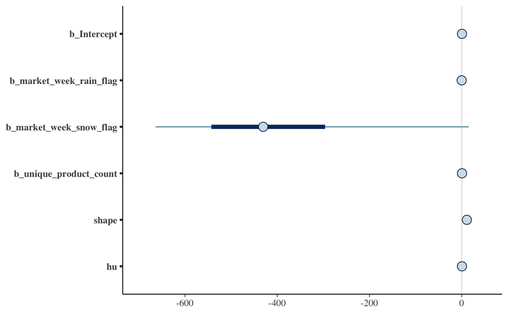

2. As the number of different available products at the market increases, do sales of fresh produce go up or down?

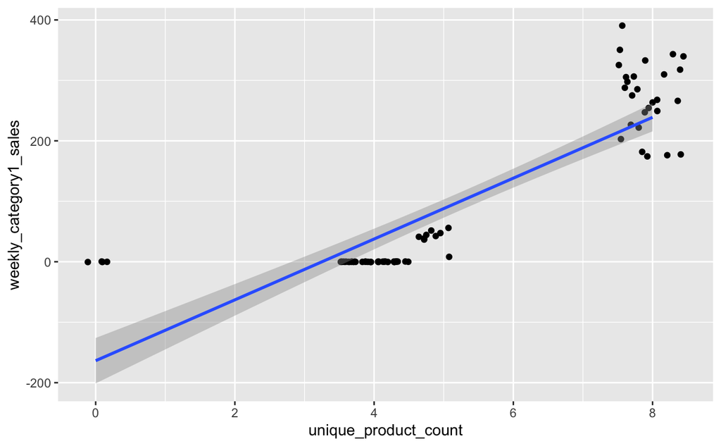

```r
market.data %>%
  mutate(unique_product_count = as.numeric(unique_product_count)) %>%
  ggplot(aes(x = unique_product_count, y = weekly_category1_sales)) +
  geom_point(position = position_jitter(width = 0.5, height = 0.5)) +
  geom_smooth(method = "glm")
```

Fit a model:

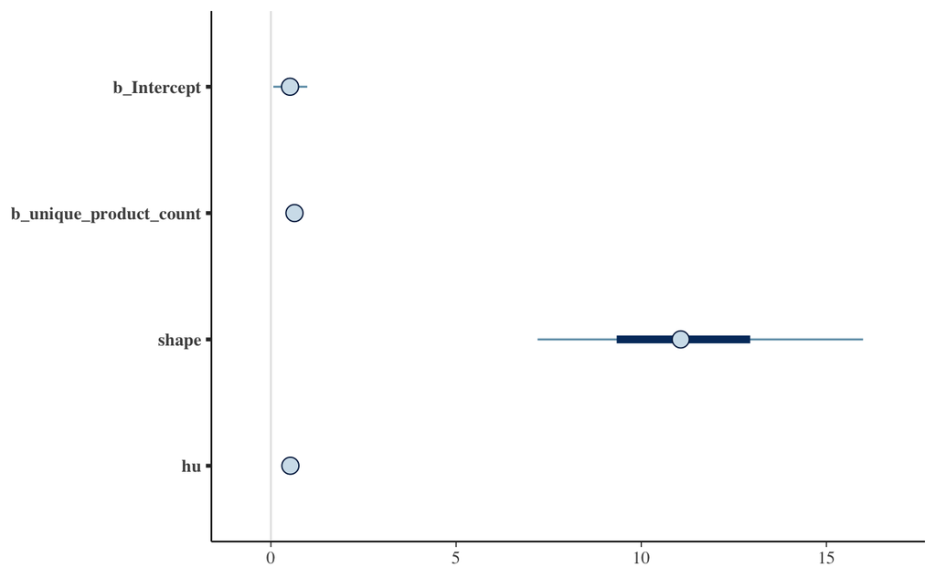

# How Do Sales Vary by Customer Zip Code, Market Distance, and Demographic Data?

Can we integrate demographic data into this analysis? We could group all sales by zip code, be we might get more meaningful answers if we group sales by customer, then look at the summary statistics and distributions of per-customer sales totals by zip code.

We can calculate the distance from the market by calculating the distances between the market location and some location associated with each zip code, such as a centrally located latittude and longitude.

For this example, we will summarize the sales per customer, then join in the demographic data to every customer’s record.

```sql
SELECT
  c.customer_id,
  c.customer_zip,
  DATEDIFF(MAX(market_date), MIN(market_date)) AS customer_durration_days,
  COUNT(DISTINCT market_date) AS number_of_markets,
  ROUND(SUM(quantity * cost_to_customer_per_qty), 2) AS total_spent,
  ROUND(SUM(quantity * cost_to_customer_per_qty) / COUNT(DISTINCT market_date), 2)
    AS average_spent_per_market
FROM farmers_market.customer AS c
  LEFT JOIN farmers_market.customer_purchases AS CP
    ON cp.customer_id = c.customer_id
GROUP BY c.customer_id
```

| customer_id | customer_zip | customer_durration_days | number_of_markets | total_spent | average_spent_per_market |
| --- | --- | --- | --- | --- | --- |
| 1 | 22801 | 553 | 107 | 3530.92 | 33.00 |
| 2 | 22821 | 553 | 117 | 4179.45 | 35.72 |
| 3 | 22821 | 553 | 112 | 3832.16 | 34.22 |
| 4 | 22801 | 549 | 115 | 3561.63 | 30.97 |
| 5 | 22801 | 556 | 113 | 3932.83 | 34.80 |
| 6 | 22801 | 556 | 95 | 3016.47 | 31.75 |
| 7 | 22821 | 556 | 100 | 2921.17 | 29.21 |
| 8 | 22821 | 553 | 101 | 3403.68 | 33.70 |
| 9 | 22801 | 556 | 92 | 3015.73 | 32.78 |
| 10 | 22801 | 556 | 96 | 2495.41 | 25.99 |

[output cut: 16 more lines]

# How does Product Price Distribution Affect Market Sales?

“What does our distribution of product prices look like at the market? Are our low-priced items or high-priced items generating more sales for the market?” We can answer these questions with window functions.

First, we want to get the product pricing details prior to completing the level of summarization required to answer the questions.

```sql
SELECT
  p.product_id,
  p.product_name,
  p.product_category_id,
  p.product_qty_type,
  vi.vendor_id,
  vi.market_date,
  SUM(vi.quantity),
  AVG(vi.original_price)
FROM farmers_market.product AS p
  LEFT JOIN farmers_market.vendor_inventory AS vi
  ON vi.product_id = p.product_id
GROUP BY
  p.product_id,
  p.product_name,
  p.product_category_id,
  p.product_qty_type,
  vi.vendor_id,
  vi.market_date
```

| product_id | product_name | product_category_id | product_qty_type | vendor_id | market_date | SUM(vi.quantity) | AVG(vi.original_price) |
| --- | --- | --- | --- | --- | --- | --- | --- |
| 1 | Habanero Peppers - Organic | 1 | lbs | 7 | 2019-07-03 | 7.38 | 6.99 |
| 1 | Habanero Peppers - Organic | 1 | lbs | 7 | 2019-07-06 | 10.96 | 6.99 |
| 1 | Habanero Peppers - Organic | 1 | lbs | 7 | 2019-07-10 | 13.08 | 6.99 |
| 1 | Habanero Peppers - Organic | 1 | lbs | 7 | 2019-07-13 | 10.22 | 6.99 |
| 1 | Habanero Peppers - Organic | 1 | lbs | 7 | 2019-07-17 | 10.59 | 6.99 |
| 1 | Habanero Peppers - Organic | 1 | lbs | 7 | 2019-07-20 | 9.04 | 6.99 |
| 1 | Habanero Peppers - Organic | 1 | lbs | 7 | 2019-07-24 | 10.66 | 6.99 |
| 1 | Habanero Peppers - Organic | 1 | lbs | 7 | 2019-07-27 | 6.76 | 6.99 |
| 1 | Habanero Peppers - Organic | 1 | lbs | 7 | 2019-07-31 | 11.23 | 6.99 |
| 1 | Habanero Peppers - Organic | 1 | lbs | 7 | 2019-08-03 | 10.72 | 6.99 |

[output cut: 802 more lines]

Because we are looking at prices per season over time, we need to pull in the `market_season` from the `market_date_info` table.

```sql
SELECT
  p.product_id,
  p.product_name,
  p.product_category_id,
  p.product_qty_type,
  vi.vendor_id,
  MIN(MONTH(vi.market_date)) AS month_market_season_sort,
  mdi.market_season,
  mdi.market_year,
  SUM(vi.quantity),
  AVG(vi.original_price)
FROM farmers_market.product AS p
  LEFT JOIN farmers_market.vendor_inventory AS vi
    ON vi.product_id = p.product_id
  LEFT JOIN farmers_market.market_date_info AS mdi
    ON vi.market_date = mdi.market_date
GROUP BY
  p.product_id,
  p.product_name,
  p.product_category_id,
  p.product_qty_type,
  vi.vendor_id,
  mdi.market_year,
  mdi.market_season
```

| product_id | product_name | product_category_id | product_qty_type | vendor_id | month_market_season_sort | market_season | market_year | SUM(vi.quantity) | AVG(vi.original_price) |
| --- | --- | --- | --- | --- | --- | --- | --- | --- | --- |
| 1 | Habanero Peppers - Organic | 1 | lbs | 7 | 7 | Summer/Early Fall | 2019 | 249.94 | 6.99 |
| 1 | Habanero Peppers - Organic | 1 | lbs | 7 | 7 | Summer/Early Fall | 2020 | 288.01 | 6.99 |
| 2 | Jalapeno Peppers - Organic | 1 | lbs | 7 | 7 | Summer/Early Fall | 2019 | 748.33 | 3.49 |
| 2 | Jalapeno Peppers - Organic | 1 | lbs | 7 | 7 | Summer/Early Fall | 2020 | 807.90 | 3.49 |
| 3 | Poblano Peppers - Organic | 1 | unit | 7 | 7 | Summer/Early Fall | 2019 | 1750.00 | 0.50 |
| 3 | Poblano Peppers - Organic | 1 | unit | 7 | 7 | Summer/Early Fall | 2020 | 1730.00 | 0.50 |
| 4 | Banana Peppers - Jar | 3 | unit | 7 | 4 | Spring | 2019 | 610.00 | 4.00 |
| 4 | Banana Peppers - Jar | 3 | unit | 7 | 6 | Summer/Early Fall | 2019 | 1610.00 | 4.00 |
| 4 | Banana Peppers - Jar | 3 | unit | 7 | 11 | Late Fall/Holiday | 2019 | 630.00 | 4.00 |
| 4 | Banana Peppers - Jar | 3 | unit | 7 | 3 | Spring | 2020 | 970.00 | 4.00 |

[output cut: 33 more lines]